# Estatística Bayesiana — síntese para consulta

## 2.7 Resumir a posteriori

Com as amostras, qualquer resumo é uma conta simples sobre elas:

- **ponto:** média (perda quadrática), mediana (perda absoluta) ou moda;
- **intervalo de credibilidade de 95%:** entre os quantis 2,5% e 97,5%;
- **HPD de 95%:** o **menor** intervalo com 95% de probabilidade. Igual ao anterior em posterioris simétricas; melhor nas assimétricas (variâncias, proporções perto de 0 ou 1);
- **qualquer função** dos parâmetros: calcule em cada amostra e resuma (ex.: saldo esperado com São Januário lotado, 22 mil).

Leitura correta: “dado o modelo e os dados, há 95% de probabilidade de $\beta_1$ (o efeito de mil torcedores) estar entre a e b”. Leitura de torcedor: “é certeza”. Não é.

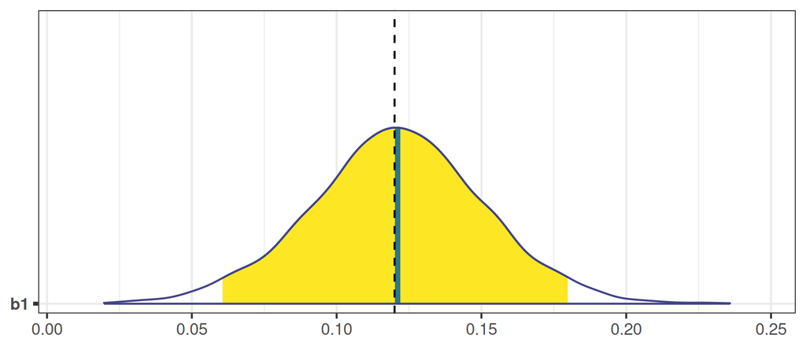

```r
am <- rstan::extract(fit)     # lista: um vetor por parâmetro
c(media = mean(am$b1), mediana = median(am$b1))
##     media   mediana
## 0.1209980 0.1211246
quantile(am$b1, c(.025, .975))                     # credibilidade
##       2.5%      97.5%
## 0.06066077 0.17976175
HPDinterval(as.mcmc(cbind(b1 = am$b1)), 0.95)      # HPD
##         lower     upper
## b1 0.06119712 0.1800741
## attr(,"Probability")
## [1] 0.95

saldo_lotado <- am$b0 + am$b1 * 22   # função dos parâmetros
quantile(saldo_lotado, c(.025, .5, .975))
##     2.5%      50%    97.5%
## 1.949512 2.591988 3.240279

mcmc_areas(boa, pars = "b1", prob = 0.95) +
  geom_vline(xintercept = 0.12, linetype = 2)  # verdadeiro
```

## 2.8 Adequação: o modelo reproduz os dados?

Convergir **não** quer dizer que o modelo é bom. A **checagem preditiva a posteriori** simula dados novos ($y^{rep}$) com cada amostra da posteriori e compara com os reais.

- **Gráfico:** a densidade dos $y^{rep}$ deve cobrir a de $y$.
- **Valor-p bayesiano:** $P\big(T(y^{rep}) \ge T(y) \mid y\big)$ para uma estatística $T$ (média, DP, mínimo, máximo…). Perto de 0,5 é bom; perto de 0 ou 1 mostra o que o modelo **não** captura.
- Em modelos hierárquicos, verifique em **vários níveis**: global, por grupo e por indivíduo.

Atenção

- Escolha estatísticas que o modelo **não** ajusta diretamente: a média quase sempre passa; o máximo, o mínimo e a assimetria revelam mais.
- No gráfico, $y$ tem “degraus” (o saldo é inteiro) e $y^{rep}$ é liso: é a aproximação Normal aparecendo. Para gols, o modelo mais fiel seria Poisson para os gols de cada time (Skellam para o saldo).

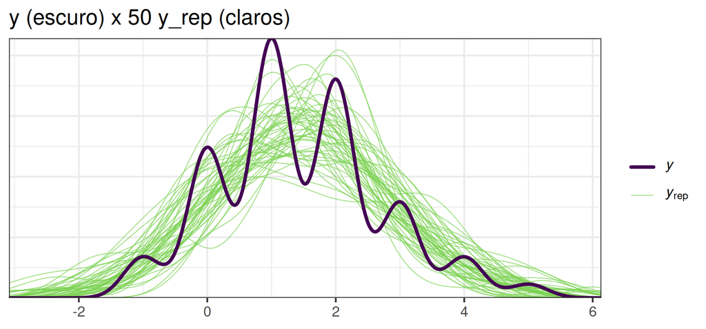

```r
y_rep <- am$y_rep             # amostras x observações
ppc_dens_overlay(y, y_rep[1:50, ]) +
  ggtitle("y (escuro) x 50 y_rep (claros)")
```

```r
p_bayes <- function(T) mean(apply(y_rep, 1, T) >= T(y))
sapply(list(media = mean, dp = sd, minimo = min, maximo = max), p_bayes)
##   media      dp  minimo  maximo
## 0.47000 0.53875 0.17625 0.21725
```

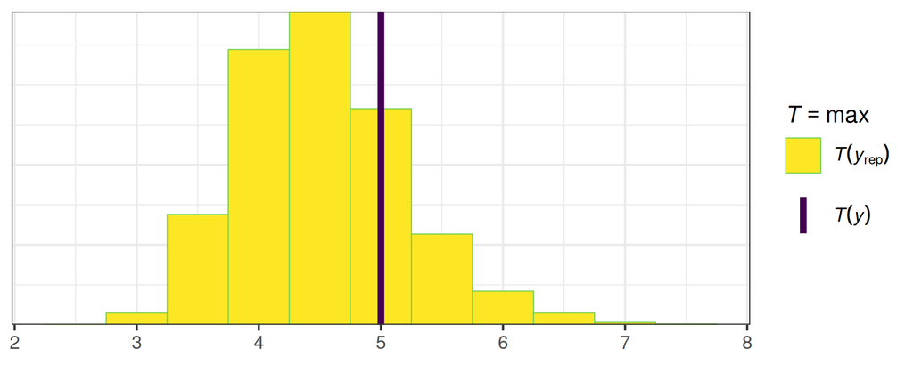

```r
# onde cai o máximo real entre os simulados?
ppc_stat(y, y_rep, stat = "max", binwidth = 0.5)
```

Para aprofundar

- [Gabry et al. (2019): visualização no fluxo bayesiano](https://doi.org/10.1111/rssa.12378) · [Checagens preditivas no bayesplot](https://mc-stan.org/bayesplot/articles/graphical-ppcs.html)
- Aula: [Tópico 9 – Avaliação e extensões de modelos](https://drive.google.com/file/d/1CjiIYuMoV3VE4JcJXMP0oE8bg8VZT-K9/view)

## 2.9 Comparação de modelos

Compara modelos pela capacidade de **prever** (menor critério = melhor):

| Critério | Ideia | Cuidado |
| --- | --- | --- |
| **DIC** | desvio médio + $p_D$ (penaliza a complexidade) | supõe posteriori ~normal; usa só a média |
| **WAIC** | ajuste por observação − penalidade (variância do `log_lik`) | instável com observações influentes |
| **LOO** (PSIS) | aproxima “tirar uma observação e prever” | confiável se Pareto $k < 0{,}7$ |
| **Fator de Bayes** | razão das evidências $p(y\mid M_1)/p(y\mid M_0)$ | muito sensível à priori |

$\text{DIC} = \bar D + p_D$, com $D(\theta) = -2\log L(\theta)$ e $p_D = \bar D - D(\bar\theta)$.

Atenção

- No LOO, olhe a **diferença** (`elpd_diff`) junto com o **erro-padrão**: diferença menor que ~2 EP não separa os modelos.
- Pareto $k > 0{,}7$: a aproximação falhou para aquela observação. Em modelos com um parâmetro por observação (ou grupo), faça o LOO **por grupo**.

```stan
data { int<lower=1> N; vector[N] x; vector[N] y; }
parameters { real b0; real<lower=0> sigma; }
model {
  b0 ~ normal(0, 2); sigma ~ normal(0, 2);
  y ~ normal(b0, sigma);       // sem o público
}
generated quantities {
  vector[N] log_lik;
  for (i in 1:N) log_lik[i] = normal_lpdf(y[i] | b0, sigma);
}
```

```r
fit0 <- sampling(modelo_nulo, data = dados,
                 seed = 2026, refresh = 0)

ll1 <- extract_log_lik(fit)       # amostras x observações
ll0 <- extract_log_lik(fit0)
cad <- rep(1:4, each = 1000)      # cadeia de cada amostra
loo1 <- loo(ll1, r_eff = relative_eff(exp(ll1), cad))
loo0 <- loo(ll0, r_eff = relative_eff(exp(ll0), cad))
loo_compare(list(com_torcida = loo1, sem_torcida = loo0))
##        model elpd_diff se_diff p_worse diag_diff diag_elpd
##  com_torcida       0.0     0.0      NA
##  sem_torcida      -6.3     3.6    0.96   N < 100
# diferença ~1,7 erro-padrão: indício a favor da torcida, não certeza
sum(loo1$diagnostics$pareto_k > 0.7)   # observações problemáticas
## [1] 0
c(com = waic(ll1)$estimates["waic", 1],
  sem = waic(ll0)$estimates["waic", 1])
##      com      sem
## 191.4159 204.0804

# DIC "à mão" (como no material da disciplina)
dic <- function(ll, ll_media) {
  D_bar <- mean(-2 * rowSums(ll))
  D_hat <- -2 * sum(ll_media)
  c(DIC = 2 * D_bar - D_hat, pD = D_bar - D_hat)
}
mu_hat <- mean(am$b0) + mean(am$b1) * x
dic(ll1, dnorm(y, mu_hat, mean(am$sigma), log = TRUE))
##        DIC         pD
## 191.338079   2.917549
```

Para aprofundar

- [Vehtari, Gelman & Gabry (2017): LOO e WAIC](https://doi.org/10.1007/s11222-016-9696-4) · [Pacote loo](https://mc-stan.org/loo/) · [Spiegelhalter et al. (2002): DIC](https://doi.org/10.1111/1467-9868.00353) · [Kass & Raftery (1995): fator de Bayes](https://doi.org/10.1080/01621459.1995.10476572)
- Aula: [Tópico 7 – Comparação bayesiana de modelos](https://drive.google.com/file/d/1vXcrRwK0_qmrtckzOr7PdusQZ3z-hPSA/view) · Códigos: [Módulo VI – Regressão, DIC e fator de Bayes](https://drive.google.com/file/d/1X-lk5_80cNhDkm61Q_AnvNWv8iuMBH2d/view)

## 2.10 Testes de hipóteses

Hipóteses são **regiões do parâmetro**: $H_0: \theta \in \Theta_0$ × $H_1: \theta \in \Theta_1$. A resposta é a **probabilidade a posteriori** de cada uma, e não “rejeita/não rejeita”.

- $P(H_1 \mid y)$ = proporção de amostras em $\Theta_1$;
- **chance a posteriori:** $P(H_1\mid y)/P(H_0\mid y)$;
- **fator de Bayes:** chance a posteriori ÷ chance a priori (o quanto os dados mudaram a crença);
- **ROPE** (região de equivalência prática): faixa em que a diferença é desprezível *na prática*, como ±0,02 gol por mil torcedores. Pergunta: $P(\theta \in \text{ROPE} \mid y)$.

Atenção

- Hipótese pontual ($\theta = 0$ exatamente) tem probabilidade zero com priori contínua: use ROPE ou fator de Bayes com priori mista.
- O ROPE é uma decisão do pesquisador, tomada **antes** de ver o resultado (e não depois de ver que o Vasco perdeu).
- A chance de vitória vem da **preditiva**: ela inclui a incerteza dos parâmetros **e** o acaso do jogo ($\sigma$). Por isso é bem menor que $P(\beta_1 > 0 \mid y)$.

```r
b1 <- am$b1
c("P(b1 > 0 | y)"      = mean(b1 > 0),       # a torcida ajuda?
  "P(b1 > 0,05 | y)"   = mean(b1 > 0.05),
  "P(|b1| < 0,02 | y)" = mean(abs(b1) < 0.02))  # ROPE
##      P(b1 > 0 | y)   P(b1 > 0,05 | y) P(|b1| < 0,02 | y)
##            1.00000            0.98950            0.00025

# fator de Bayes, H1: b1 > 0 contra H0: b1 <= 0
p_pri  <- 1 - pnorm(0, 0, 0.5)      # P(H1) pela priori = 0,5
p_post <- mean(b1 > 0)              # P(H1) pela posteriori
p_post <- min(p_post, 1 - 1 / (2 * length(b1)))  # evita /0
(p_post / (1 - p_post)) / (p_pri / (1 - p_pri))   # FB
## [1] 7999

# A pergunta do torcedor: chance de vencer com 20 mil?
y_novo <- rnorm(length(b1), am$b0 + am$b1 * 20, am$sigma)
c(vitoria = mean(y_novo >= 0.5),          # saldo arredondado >= 1
  empate  = mean(abs(y_novo) < 0.5),
  derrota = mean(y_novo <= -0.5))
## vitoria  empate derrota
##   0.931   0.060   0.009
```

Para aprofundar

- [Kruschke (2018): ROPE e HDI](https://doi.org/10.1177/2515245918771304)
- Aula: [Tópico 8 – Testes de hipóteses](https://drive.google.com/file/d/1NKJniw-0VT7hcXu46Td6p_Z0sv8OHNwR/view) · Códigos: [Módulo VII – Beta-Bernoulli e fator de Bayes](https://drive.google.com/file/d/1kJyZBJ0N_j0VJuEWp5SsAjKs6ndbsHQ9/view)

## 2.11 Sensibilidade e modelos hierárquicos

**Sensibilidade:** refaça a análise com outra priori razoável. Se a conclusão muda, diga isso; se não muda, a conclusão é robusta. Com muitos dados, a verossimilhança domina; com poucos, a priori pesa.

Ao lado, três prioris para $\beta_1$: a neutra do modelo, uma **de torcedor** (cada mil torcedores valem +0,3 gol, com muita certeza) e uma **de rival** (a torcida atrapalha, −0,1). Prioris muito confiantes e erradas puxam a posteriori mesmo com 60 jogos.

**Modelos hierárquicos:** quando há grupos (escolas, famílias, ambientes), os efeitos dos grupos vêm de uma distribuição comum, cuja variância também é estimada:

$$\gamma_j \sim N(0, \tau^2),\qquad \tau \sim \text{half-Normal}(0, s)$$

Ex.: o efeito de cada adversário no saldo do Vasco. Isso gera o **partial pooling**: adversário que o Vasco enfrentou poucas vezes é “puxado” para a média geral, por um fator $\tau^2/(\tau^2 + \sigma^2/n_j)$. Fica entre estimar cada grupo isolado (*no pooling*) e ignorar os grupos (*complete pooling*).

Atenção

- Restrição de identificabilidade: em $y = \mu + \tau_i + e$, some uma constante a $\mu$ e tire dos $\tau_i$, e o ajuste é o mesmo. Use $\sum \tau_i = 0$ ou uma priori centrada em zero.
- Com $\tau$ perto de zero aparece o “funil” (divergências): use a forma **não centrada**, $\gamma_j = \tau z_j$, $z_j \sim N(0,1)$.

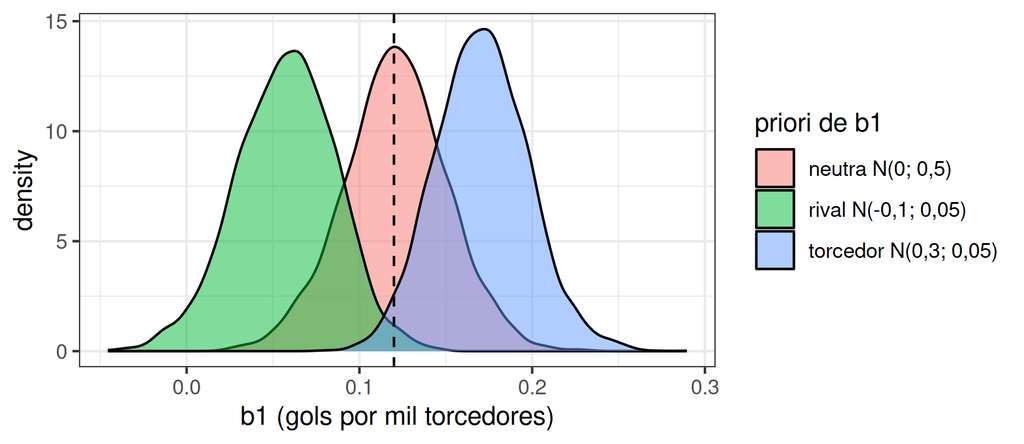

```r
# mesma análise, trocando só a priori de b1
refit <- function(priori) {
  codigo <- sub("b1    ~ normal(0, 0.5);", priori,
                modelo_reg@model_code, fixed = TRUE)
  f <- sampling(stan_model(model_code = codigo), data = dados,
                seed = 2026, refresh = 0)
  rstan::extract(f)$b1
}
b1_torcedor <- refit("b1 ~ normal(0.3, 0.05);")
b1_rival    <- refit("b1 ~ normal(-0.1, 0.05);")
sapply(list(neutra = am$b1, torcedor = b1_torcedor,
            rival = b1_rival), mean)
##     neutra   torcedor      rival
## 0.12099802 0.17091085 0.05756525

d <- rbind(data.frame(b1 = am$b1,        priori = "neutra N(0; 0,5)"),
           data.frame(b1 = b1_torcedor,  priori = "torcedor N(0,3; 0,05)"),
           data.frame(b1 = b1_rival,     priori = "rival N(-0,1; 0,05)"))
ggplot(d, aes(b1, fill = priori)) + geom_density(alpha = .5) +
  geom_vline(xintercept = 0.12, linetype = 2) +
  labs(fill = "priori de b1", x = "b1 (gols por mil torcedores)")
```

A priori neutra acerta perto do valor verdadeiro (tracejado). As prioris confiantes “ganham a discussão” contra 60 jogos e puxam a posteriori para o seu lado. **Lição:** priori informativa precisa de justificativa (dados anteriores, literatura), não de paixão.

```stan
// esqueleto: efeito de cada adversário (grupo), não centrado
parameters {
  real mu; vector[J] z;
  real<lower=0> tau; real<lower=0> sigma;
}
transformed parameters { vector[J] gamma = tau * z; }
model {
  z ~ std_normal();                  // gamma ~ N(0, tau^2)
  tau ~ normal(0, 1); sigma ~ normal(0, 2);
  y ~ normal(mu + gamma[adversario], sigma);
}
```

Para aprofundar

- [BDA3, cap. 5 (modelos hierárquicos)](https://sites.stat.columbia.edu/gelman/book/BDA3.pdf) · [Bayes Rules!, caps. 15–19](https://www.bayesrulesbook.com/)
- Aula: [Tópico 9 – Avaliação e extensões (hierárquicos, partial pooling)](https://drive.google.com/file/d/1CjiIYuMoV3VE4JcJXMP0oE8bg8VZT-K9/view) · Códigos: [Módulo VII – efeito da priori e do tamanho amostral](https://drive.google.com/file/d/1kJyZBJ0N_j0VJuEWp5SsAjKs6ndbsHQ9/view)

# 3. Tabela de distribuições

Notação e parametrização do BDA3 (apêndice A), com o que muda no R e no Stan. Digite para filtrar (ex.: “gama”, “conjugada”, “desvio”).

As três armadilhas de parametrização

- **Normal:** o livro usa a **variância** $\sigma^2$; R (`dnorm(x, mean, sd)`) e Stan (`normal(mu, sigma)`) usam o **desvio-padrão**; o JAGS (`dnorm(mu, tau)`) usa a **precisão** $1/\sigma^2$.
- **Gama:** o livro usa $\beta$ = **taxa** (inverso da escala). R: `dgamma(x, shape, rate)` (cuidado: `dgamma(x, a, b)` posicional é a taxa, mas `scale = 1/b` também é aceito). Stan: `gamma(alpha, beta)`, taxa.
- **Binomial negativa:** há várias. A do livro coincide com `neg_binomial(alpha, beta)` do Stan; no R, `dnbinom(x, size = alpha, prob = beta/(beta+1))` ou `mu = alpha/beta`.

### Contínuas

| Distribuição | Densidade | Média · Variância · Moda | R | Stan | Uso típico / cuidado |
| --- | --- | --- | --- | --- | --- |
| Uniforme $U(a,b)$ | $\frac{1}{b-a}$, $\theta\in[a,b]$ | $\frac{a+b}{2}$ · $\frac{(b-a)^2}{12}$ · — | `dunif(x, a, b)` | `uniform(a, b)` | priori “plana” com limites; no Stan, declare os limites no parâmetro. $U(0,1)=\text{Beta}(1,1)$ |
| Normal $N(\mu,\sigma^2)$ | $\frac{1}{\sqrt{2\pi}\sigma}e^{-\frac{(\theta-\mu)^2}{2\sigma^2}}$ | $\mu$ · $\sigma^2$ · $\mu$ | `dnorm(x, mu, sd)` | `normal(mu, sigma)` | verossimilhança de dados contínuos; priori de médias e efeitos. **R/Stan: desvio-padrão** |
| Half-Normal | $\frac{2}{\sqrt{2\pi}\sigma}e^{-\frac{\theta^2}{2\sigma^2}}$, $\theta\ge0$ | $\sigma\sqrt{2/\pi}$ · $\sigma^2(1-\frac{2}{\pi})$ · 0 | `2*dnorm(x, 0, s)` | `real<lower=0>` + `normal(0, s)` | **priori de desvio-padrão** (padrão fracamente informativo) |
| Lognormal | $\frac{1}{\theta\sigma\sqrt{2\pi}}e^{-\frac{(\log\theta-\mu)^2}{2\sigma^2}}$ | $e^{\mu+\sigma^2/2}$ · $(e^{\sigma^2}-1)e^{2\mu+\sigma^2}$ · $e^{\mu-\sigma^2}$ | `dlnorm(x, meanlog, sdlog)` | `lognormal(mu, sigma)` | dados positivos e assimétricos; $\mu,\sigma$ estão na escala do log |
| Gama $\text{Gama}(\alpha,\beta)$ | $\frac{\beta^\alpha}{\Gamma(\alpha)}\theta^{\alpha-1}e^{-\beta\theta}$ | $\frac{\alpha}{\beta}$ · $\frac{\alpha}{\beta^2}$ · $\frac{\alpha-1}{\beta}$ ($\alpha\ge1$) | `dgamma(x, shape, rate)` | `gamma(alpha, beta)` | **conjugada da Poisson**; priori de precisão (JAGS); com $\alpha>1$, afasta desvios-padrão do zero |
| Exponencial $\text{Expon}(\beta)$ | $\beta e^{-\beta\theta}$ | $\frac1\beta$ · $\frac{1}{\beta^2}$ · 0 | `dexp(x, rate)` | `exponential(beta)` | $=\text{Gama}(1,\beta)$; priori de desvio-padrão; tempos de espera |
| Qui-quadrado $\chi^2_\nu$ | $\frac{2^{-\nu/2}}{\Gamma(\nu/2)}\theta^{\nu/2-1}e^{-\theta/2}$ | $\nu$ · $2\nu$ · $\nu-2$ ($\nu\ge2$) | `dchisq(x, df)` | `chi_square(nu)` | $=\text{Gama}(\nu/2,\,1/2)$ |
| Inv-Gama $\text{Inv-gama}(\alpha,\beta)$ | $\frac{\beta^\alpha}{\Gamma(\alpha)}\theta^{-(\alpha+1)}e^{-\beta/\theta}$ | $\frac{\beta}{\alpha-1}$ ($\alpha>1$) · $\frac{\beta^2}{(\alpha-1)^2(\alpha-2)}$ ($\alpha>2$) · $\frac{\beta}{\alpha+1}$ | não há no base: `1/rgamma(n, a, rate = b)` | `inv_gamma(alpha, beta)` | **conjugada da variância da Normal**; evite $\text{Inv-gama}(\varepsilon,\varepsilon)$ em hierárquicos (Gelman, 2006) |
| Inv-$\chi^2$ $\text{Inv-}\chi^2_\nu$ | $\frac{2^{-\nu/2}}{\Gamma(\nu/2)}\theta^{-(\nu/2+1)}e^{-1/(2\theta)}$ | $\frac{1}{\nu-2}$ ($\nu>2$) · $\frac{2}{(\nu-2)^2(\nu-4)}$ ($\nu>4$) · $\frac{1}{\nu+2}$ | não há no base | `inv_chi_square(nu)` | $=\text{Inv-gama}(\nu/2,\,1/2)$ |
| Inv-$\chi^2$ escalonada $\text{Inv-}\chi^2(\nu,s^2)$ | $\frac{(\nu/2)^{\nu/2}}{\Gamma(\nu/2)}s^\nu\theta^{-(\nu/2+1)}e^{-\nu s^2/(2\theta)}$ | $\frac{\nu s^2}{\nu-2}$ · $\frac{2\nu^2s^4}{(\nu-2)^2(\nu-4)}$ · $\frac{\nu s^2}{\nu+2}$ | não há no base | `scaled_inv_chi_square(nu, s)` | $=\text{Inv-gama}(\nu/2,\,\nu s^2/2)$; priori de variância “como $\nu$ observações com variância $s^2$” |
| *t* de Student $t_\nu(\mu,\sigma^2)$ | $\frac{\Gamma(\frac{\nu+1}{2})}{\Gamma(\frac\nu2)\sqrt{\nu\pi}\sigma}\Big(1+\frac1\nu\big(\frac{\theta-\mu}{\sigma}\big)^2\Big)^{-\frac{\nu+1}{2}}$ | $\mu$ ($\nu>1$) · $\frac{\nu}{\nu-2}\sigma^2$ ($\nu>2$) · $\mu$ | `dt((x-mu)/s, df)/s` | `student_t(nu, mu, sigma)` | verossimilhança **robusta** a valores extremos; half-*t* para desvios-padrão |
| Cauchy $=t_1(\mu,\sigma^2)$ | $\frac{1}{\pi\sigma\left[1+\left(\frac{\theta-\mu}{\sigma}\right)^2\right]}$ | não existem · não existe · $\mu$ | `dcauchy(x, loc, scale)` | `cauchy(mu, sigma)` | caudas muito pesadas |
| Half-Cauchy | $\frac{2}{\pi\sigma\left[1+(\theta/\sigma)^2\right]}$, $\theta\ge0$ | não existem · — · 0 | `2*dcauchy(x, 0, s)` | `real<lower=0>` + `cauchy(0, s)` | priori de desvio-padrão em hierárquicos (Gelman, 2006); cauda pesada pode travar cadeias com poucos grupos |
| Beta $\text{Beta}(\alpha,\beta)$ | $\frac{\Gamma(\alpha+\beta)}{\Gamma(\alpha)\Gamma(\beta)}\theta^{\alpha-1}(1-\theta)^{\beta-1}$ | $\frac{\alpha}{\alpha+\beta}$ · $\frac{\alpha\beta}{(\alpha+\beta)^2(\alpha+\beta+1)}$ · $\frac{\alpha-1}{\alpha+\beta-2}$ | `dbeta(x, a, b)` | `beta(alpha, beta)` | **conjugada da Binomial/Bernoulli**; $\alpha,\beta$ = “sucessos e fracassos a priori” |

### Discretas

| Distribuição | Função de probabilidade | Média · Variância · Moda | R | Stan | Uso típico / cuidado |
| --- | --- | --- | --- | --- | --- |
| Bernoulli $\text{Bern}(p)$ | $p^\theta(1-p)^{1-\theta}$, $\theta\in\{0,1\}$ | $p$ · $p(1-p)$ · — | `dbinom(x, 1, p)` | `bernoulli(p)` | dado 0/1; com preditores: `bernoulli_logit` |
| Binomial $\text{Bin}(n,p)$ | $\binom{n}{\theta}p^\theta(1-p)^{n-\theta}$ | $np$ · $np(1-p)$ · $\lfloor(n+1)p\rfloor$ | `dbinom(x, n, p)` | `binomial(n, p)` | nº de sucessos em $n$ tentativas; conjugada: **Beta** |
| Poisson $\text{Poisson}(\lambda)$ | $\frac{\lambda^\theta e^{-\lambda}}{\theta!}$ | $\lambda$ · $\lambda$ · $\lfloor\lambda\rfloor$ | `dpois(x, lambda)` | `poisson(lambda)` | contagens; média = variância (se variância > média: sobredispersão → Binomial negativa); conjugada: **Gama** |
| Binomial negativa $\text{Neg-bin}(\alpha,\beta)$ | $\binom{\theta+\alpha-1}{\alpha-1}\left(\frac{\beta}{\beta+1}\right)^{\alpha}\left(\frac{1}{\beta+1}\right)^{\theta}$ | $\frac{\alpha}{\beta}$ · $\frac{\alpha(\beta+1)}{\beta^2}$ · — | `dnbinom(x, size = a, prob = b/(b+1))` | `neg_binomial(alpha, beta)` ou `neg_binomial_2(mu, phi)` | **contagens com sobredispersão**; = mistura Poisson–Gama. Várias parametrizações! |
| Geométrica $\text{Geom}(p)$ | $p(1-p)^\theta$, $\theta=0,1,\dots$ | $\frac{1-p}{p}$ · $\frac{1-p}{p^2}$ · 0 | `dgeom(x, p)` | `neg_binomial(1, p/(1-p))` | nº de fracassos antes do 1º sucesso; caso $\alpha=1$ da Binomial negativa |
| Beta-binomial $\text{Beta-bin}(n,\alpha,\beta)$ | $\binom{n}{\theta}\frac{B(\theta+\alpha,\;n-\theta+\beta)}{B(\alpha,\beta)}$ | $\frac{n\alpha}{\alpha+\beta}$ · $\frac{n\alpha\beta(\alpha+\beta+n)}{(\alpha+\beta)^2(\alpha+\beta+1)}$ · — | `extraDistr::dbbinom(x, n, a, b)` | `beta_binomial(n, alpha, beta)` | **preditiva a posteriori** do modelo Beta–Binomial; proporções com sobredispersão |
| Multinomial $\text{Multin}(n;p_1..p_k)$ | $\frac{n!}{\prod_j\theta_j!}\prod_j p_j^{\theta_j}$ | $E=np_j$ · $np_j(1-p_j)$; cov $-np_ip_j$ · — | `dmultinom(x, n, p)` | `multinomial(p)` | contagens em $k$ categorias; conjugada: **Dirichlet** |

### Multivariadas

| Distribuição | Densidade | Média · Variância | R | Stan | Uso típico / cuidado |
| --- | --- | --- | --- | --- | --- |
| Normal multivariada $N(\mu,\Sigma)$ | $(2\pi)^{-d/2}\lvert\Sigma\rvert^{-1/2}e^{-\frac12(\theta-\mu)^\top\Sigma^{-1}(\theta-\mu)}$ | $\mu$ · $\Sigma$ | `mvtnorm::dmvnorm(x, mu, Sigma)` | `multi_normal(mu, Sigma)` / `multi_normal_cholesky` | efeitos correlacionados, ex.: valores genéticos $u\sim N(0, K\sigma^2_g)$ com matriz de parentesco $K$ |
| Dirichlet $\text{Dir}(\alpha_1..\alpha_k)$ | $\frac{\Gamma(\alpha_0)}{\prod_j\Gamma(\alpha_j)}\prod_j\theta_j^{\alpha_j-1}$, $\alpha_0=\sum\alpha_j$ | $\frac{\alpha_j}{\alpha_0}$ · $\frac{\alpha_j(\alpha_0-\alpha_j)}{\alpha_0^2(\alpha_0+1)}$ | não há no base (`gtools::rdirichlet`) | `dirichlet(alpha)` com `simplex[K]` | proporções que somam 1 (ex.: ancestralidade no STRUCTURE); generaliza a Beta |
| Wishart $W_\nu(S)$ | $\propto\lvert W\rvert^{(\nu-k-1)/2}e^{-\frac12\text{tr}(S^{-1}W)}$ | $\nu S$ | `rWishart(n, nu, S)` | `wishart(nu, S)` | priori de matriz de **precisão** (conjugada) |
| Inv-Wishart $\text{Inv-W}_\nu(S^{-1})$ | $\propto\lvert W\rvert^{-(\nu+k+1)/2}e^{-\frac12\text{tr}(SW^{-1})}$ | $\frac{S}{\nu-k-1}$ | `MCMCpack::riwish(nu, S)` | `inv_wishart(nu, S)` | priori de matriz de **covariância** (conjugada); acopla variâncias e correlações |
| LKJ (fora da tabela do livro) | $\propto\det(R)^{\eta-1}$ | — | — | `lkj_corr_cholesky(eta)` | priori moderna para **correlações**; $\eta=1$ uniforme, $\eta>1$ puxa para a identidade. Combine com half-Normal nos desvios-padrão |

Para aprofundar

- [BDA3, apêndice A](https://sites.stat.columbia.edu/gelman/book/BDA3.pdf) (fonte da notação) · [Referência de funções do Stan](https://mc-stan.org/docs/)
- Material: [Tabela de distribuições (BDA3, ap. A)](https://drive.google.com/file/d/1jVLKrbZYQUByBkkJm7NjdA-RuEiVyc7y/view) · [Binomial negativa e geométrica](https://drive.google.com/file/d/1MJAWXQ9-Es8aI3fSt_q3_3kSPpeKEVxr/view) · Aula: [Tópico 2 – Variável aleatória](https://drive.google.com/file/d/1AY3xJSWp6AQwy0w3v3ZlY0CviEhbWcTr/view)

# 4. Mapa das distribuições

Como as distribuições se ligam. **Role para dar zoom e arraste para mover**; os botões no canto também funcionam. Setas cheias: caso particular, transformação ou limite. Tracejadas: **priori conjugada**. A Normal também é conjugada de si mesma (priori Normal para a média de dados normais).

```
%%{init: {"themeVariables": {"fontSize": "17px"}, "flowchart": {"nodeSpacing": 40, "rankSpacing": 55}}}%%
flowchart TB
  classDef disc fill:#fde8d7,stroke:#d9822b,color:#222
  classDef cont fill:#e3eef8,stroke:#2c7fb8,color:#222
  classDef mult fill:#e8f3e3,stroke:#4d9a3a,color:#222

  BER[Bernoulli]:::disc -->|"soma de n"| BIN[Binomial]:::disc
  BIN -->|"n→∞, np=λ"| POI[Poisson]:::disc
  BIN -->|"k categorias"| MUL[Multinomial]:::disc
  NB[Binomial negativa]:::disc -->|"α = 1"| GEO[Geométrica]:::disc
  POI -->|"λ ~ Gama"| NB
  BIN -->|"p ~ Beta"| BB[Beta-binomial]:::disc

  BETA[Beta]:::cont -.->|"conjugada"| BIN
  BETA -.->|"conjugada"| BER
  GAM[Gama]:::cont -.->|"conjugada"| POI
  DIR[Dirichlet]:::mult -.->|"conjugada"| MUL
  BETA -->|"k categorias"| DIR
  UNI["Uniforme(0,1)"]:::cont -->|"= Beta(1,1)"| BETA

  GAM -->|"α = 1"| EXP[Exponencial]:::cont
  GAM -->|"α=ν/2, β=1/2"| CHI[Qui-quadrado]:::cont
  GAM -->|"1/θ"| IG[Inv-Gama]:::cont
  CHI -->|"1/θ"| ICHI["Inv-χ²"]:::cont
  IG -->|"α=ν/2, β=νs²/2"| SICHI["Inv-χ² escalonada"]:::cont
  IG -.->|"conjugada (variância)"| NOR[Normal]:::cont
  T[t de Student]:::cont -->|"ν → ∞"| NOR
  T -->|"ν = 1"| CAU[Cauchy]:::cont
  NOR -->|"θ ≥ 0"| HN[Half-Normal]:::cont
  CAU -->|"θ ≥ 0"| HC[Half-Cauchy]:::cont
  NOR -->|"exp(θ)"| LN[Lognormal]:::cont

  NOR -->|"vetor"| MVN[Normal multivariada]:::mult
  WIS[Wishart]:::mult -->|"inversa"| IW[Inv-Wishart]:::mult
  IW -.->|"conjugada (covariância)"| MVN
  WIS -.->|"conjugada (precisão)"| MVN
  LKJ["LKJ (correlações)"]:::mult -->|"+ desvios-padrão"| MVN
```

# 5. Checklist para a próxima análise

1. **Pergunta e dados:** o que quero saber? Olhei os dados?
2. **Verossimilhança:** a família combina com o tipo do dado?
3. **Priori:** justificada; parametrização conferida (DP × variância × precisão); **checagem a priori** feita.
4. **Ajuste:** 4 cadeias; aquecimento descartado; testei o código com dados simulados?
5. **Convergência:** $\hat R < 1{,}01$, ESS > 400, MCSE pequeno, traço misturado, **zero divergências**.
6. **Adequação:** checagem preditiva a posteriori, inclusive em estatísticas que o modelo não ajusta (máximo, mínimo, por grupo).
7. **Comparação:** LOO/WAIC (ver Pareto $k$) ou DIC; diferença comparada ao erro-padrão.
8. **Inferência:** média ou mediana + HPD; hipóteses como probabilidades; ROPE definido antes.
9. **Sensibilidade:** outra priori razoável muda a conclusão?
10. **Relato:** modelo, priori, software, cadeias × iterações, diagnósticos e limitações.

# Referências

- Gelman, A. et al. (2013). *Bayesian Data Analysis*, 3ª ed. CRC Press. [PDF gratuito](https://sites.stat.columbia.edu/gelman/book/BDA3.pdf).
- Johnson, A. A.; Ott, M. Q.; Dogucu, M. (2022). *Bayes Rules! An Introduction to Applied Bayesian Modeling*. CRC Press. [Versão online](https://www.bayesrulesbook.com/).
- Gelman, A. (2006). Prior distributions for variance parameters in hierarchical models. *Bayesian Analysis*, 1(3), 515–534.
- Spiegelhalter, D. J. et al. (2002). Bayesian measures of model complexity and fit. *JRSS B*, 64(4), 583–639.
- Vehtari, A.; Gelman, A.; Gabry, J. (2017). Practical Bayesian model evaluation using leave-one-out cross-validation and WAIC. *Statistics and Computing*, 27, 1413–1432.
- Vehtari, A. et al. (2021). Rank-normalization, folding, and localization: an improved R-hat. *Bayesian Analysis*, 16(2), 667–718.
- Gabry, J. et al. (2019). Visualization in Bayesian workflow. *JRSS A*, 182(2), 389–402.
- Kruschke, J. K. (2018). Rejecting or accepting parameter values in Bayesian estimation. *AMPPS*, 1(2), 270–280.
- Link, W. A.; Eaton, M. J. (2012). On thinning of chains in MCMC. *Methods in Ecology and Evolution*, 3(1), 112–115.
- Carpenter, B. et al. (2017). Stan: a probabilistic programming language. *Journal of Statistical Software*, 76(1).

Material da disciplina: EST613 – Estatística Bayesiana, UFV, 2026/2. Profa. Camila Ferreira Azevedo. Tópicos 1–9 e Módulos I–VII (códigos).